# Amazon India Reviews Project

#### **Brief Description of the Project:** Performed an end-to-end analysis of Amazon India product reviews using Python. Conducted exploratory data analysis(EDA) and sentiment analysis using Natural Language Processing(NLP) tools on Amazon India product reviews. Applied NLP techniques including tokenization, stopword removal, and sentiment scoring with NLTK VADER and Hugging Face BERT based pretrained RoBERTa transformer. Created visualizations such as word clouds and statistical plots with Matplotlib and Seaborn. Demonstrated skills in data cleaning, text processing, sentiment analysis, and data visualization using libraries including pandas, numpy, NLTK, pytorch, transformers, Matplotlib and Seaborn to extract business insights and create impactful visualizations.

### Importing necessary libraries:

```python
import pandas as pd
import numpy as np
import matplotlib.pyplot as plt
import seaborn as sns

import nltk
from nltk.corpus import stopwords
from nltk.tokenize import word_tokenize
from nltk.sentiment import SentimentIntensityAnalyzer
from wordcloud import WordCloud

import torch
from transformers import AutoTokenizer, AutoModelForSequenceClassification

import warnings
warnings.filterwarnings('ignore')
```

### Reading the dataset:

```python
df = pd.read_csv(r"D:\Data Science\Projects\2. Amazon India Reviews Project\amazon.csv")
```

```python
df.head()
```

|  | product_id | product_name | category | discounted_price | actual_price | discount_percentage | rating | rating_count | about_product | user_id | user_name | review_id | review_title | review_content | img_link | product_link |
| --- | --- | --- | --- | --- | --- | --- | --- | --- | --- | --- | --- | --- | --- | --- | --- | --- |
| 0 | B07JW9H4J1 | Wayona Nylon Braided USB to Lightning Fast Cha... | Computers&Accessories\|Accessories&Peripherals\|... | ₹399 | ₹1,099 | 64% | 4.2 | 24,269 | High Compatibility : Compatible With iPhone 12... | AG3D6O4STAQKAY2UVGEUV46KN35Q,AHMY5CWJMMK5BJRBB... | Manav,Adarsh gupta,Sundeep,S.Sayeed Ahmed,jasp... | R3HXWT0LRP0NMF,R2AJM3LFTLZHFO,R6AQJGUP6P86,R1K... | Satisfied,Charging is really fast,Value for mo... | Looks durable Charging is fine tooNo complains... | https://m.media-amazon.com/images/W/WEBP_40237... | https://www.amazon.in/Wayona-Braided-WN3LG1-Sy... |
| 1 | B098NS6PVG | Ambrane Unbreakable 60W / 3A Fast Charging 1.5... | Computers&Accessories\|Accessories&Peripherals\|... | ₹199 | ₹349 | 43% | 4.0 | 43,994 | Compatible with all Type C enabled devices, be... | AECPFYFQVRUWC3KGNLJIOREFP5LQ,AGYYVPDD7YG7FYNBX... | ArdKn,Nirbhay kumar,Sagar Viswanathan,Asp,Plac... | RGIQEG07R9HS2,R1SMWZQ86XIN8U,R2J3Y1WL29GWDE,RY... | A Good Braided Cable for Your Type C Device,Go... | I ordered this cable to connect my phone to An... | https://m.media-amazon.com/images/W/WEBP_40237... | https://www.amazon.in/Ambrane-Unbreakable-Char... |
| 2 | B096MSW6CT | Sounce Fast Phone Charging Cable & Data Sync U... | Computers&Accessories\|Accessories&Peripherals\|... | ₹199 | ₹1,899 | 90% | 3.9 | 7,928 | 【 Fast Charger& Data Sync】-With built-in safet... | AGU3BBQ2V2DDAMOAKGFAWDDQ6QHA,AESFLDV2PT363T2AQ... | Kunal,Himanshu,viswanath,sai niharka,saqib mal... | R3J3EQQ9TZI5ZJ,R3E7WBGK7ID0KV,RWU79XKQ6I1QF,R2... | Good speed for earlier versions,Good Product,W... | Not quite durable and sturdy,https://m.media-a... | https://m.media-amazon.com/images/W/WEBP_40237... | https://www.amazon.in/Sounce-iPhone-Charging-C... |
| 3 | B08HDJ86NZ | boAt Deuce USB 300 2 in 1 Type-C & Micro USB S... | Computers&Accessories\|Accessories&Peripherals\|... | ₹329 | ₹699 | 53% | 4.2 | 94,363 | The boAt Deuce USB 300 2 in 1 cable is compati... | AEWAZDZZJLQUYVOVGBEUKSLXHQ5A,AG5HTSFRRE6NL3M5S... | Omkar dhale,JD,HEMALATHA,Ajwadh a.,amar singh ... | R3EEUZKKK9J36I,R3HJVYCLYOY554,REDECAZ7AMPQC,R1... | Good product,Good one,Nice,Really nice product... | Good product,long wire,Charges good,Nice,I bou... | https://m.media-amazon.com/images/I/41V5FtEWPk... | https://www.amazon.in/Deuce-300-Resistant-Tang... |
| 4 | B08CF3B7N1 | Portronics Konnect L 1.2M Fast Charging 3A 8 P... | Computers&Accessories\|Accessories&Peripherals\|... | ₹154 | ₹399 | 61% | 4.2 | 16,905 | [CHARGE & SYNC FUNCTION]- This cable comes wit... | AE3Q6KSUK5P75D5HFYHCRAOLODSA,AFUGIFH5ZAFXRDSZH... | rahuls6099,Swasat Borah,Ajay Wadke,Pranali,RVK... | R1BP4L2HH9TFUP,R16PVJEXKV6QZS,R2UPDB81N66T4P,R... | As good as original,Decent,Good one for second... | Bought this instead of original apple, does th... | https://m.media-amazon.com/images/W/WEBP_40237... | https://www.amazon.in/Portronics-Konnect-POR-1... |

```python
df.columns
```

```
Index(['product_id', 'product_name', 'category', 'discounted_price',
       'actual_price', 'discount_percentage', 'rating', 'rating_count',
       'about_product', 'user_id', 'user_name', 'review_id', 'review_title',
       'review_content', 'img_link', 'product_link'],
      dtype='object')
```

```python
df.shape
```

```
(1465, 16)
```

```python
df.size
```

```
23440
```

```python
df.info()
```

```
<class 'pandas.core.frame.DataFrame'>
RangeIndex: 1465 entries, 0 to 1464
Data columns (total 16 columns):
 #   Column               Non-Null Count  Dtype
---  ------               --------------  -----
 0   product_id           1465 non-null   object
 1   product_name         1465 non-null   object
 2   category             1465 non-null   object
 3   discounted_price     1465 non-null   object
 4   actual_price         1465 non-null   object
 5   discount_percentage  1465 non-null   object
 6   rating               1465 non-null   object
 7   rating_count         1463 non-null   object
 8   about_product        1465 non-null   object
 9   user_id              1465 non-null   object
 10  user_name            1465 non-null   object
 11  review_id            1465 non-null   object
 12  review_title         1465 non-null   object
 13  review_content       1465 non-null   object
 14  img_link             1465 non-null   object
 15  product_link         1465 non-null   object
dtypes: object(16)
memory usage: 183.3+ KB
```

#### Observations:

There are 1465 rows and 16 columns in the dataset.

The data type of all columns is object.

The columns in the datasets are: 'product_id', 'product_name', 'category', 'discounted_price', 'actual_price', 'discount_percentage', 'rating', 'rating_count', 'about_product', 'user_id', 'user_name', 'review_id', 'review_title', 'review_content', 'img_link', 'product_link'

### Changing data types of numeric columns:

```python
def convert_to_float(df, columns):

    for col in columns:
        df[col] = (
            df[col]
            .astype(str) # We make sure each value in the column is treated as a string
            .str.replace(r"[^\d\.]", "", regex=True)  # This matches anything that's not a digit or period and replaces it with a empty string
            .replace("", "0")  # Replace empty strings with zero
            .astype(float) # we now convert the cleaned string to a float data type
        )
    return df

numeric_columns = ['discounted_price', 'actual_price', 'discount_percentage', 'rating', 'rating_count']
df = convert_to_float(df, numeric_columns)

df.sample(5)
```

|  | product_id | product_name | category | discounted_price | actual_price | discount_percentage | rating | rating_count | about_product | user_id | user_name | review_id | review_title | review_content | img_link | product_link |
| --- | --- | --- | --- | --- | --- | --- | --- | --- | --- | --- | --- | --- | --- | --- | --- | --- |
| 242 | B0758F7KK7 | Caprigo Heavy Duty TV Wall Mount Bracket for 1... | Electronics\|HomeTheater,TV&Video\|Accessories\|T... | 399.0 | 999.0 | 60.0 | 4.0 | 1236.0 | TV Wall Bracket Compatibility : 14 To 32 Inch ... | AHAYLVC4ZJEXYUCSYHJGH233MBWQ,AFG7V27SPMFIYXCYQ... | Jayraj Datta,sachin kumar,Pranjal M.,Anil Ramt... | R3FOUBGTV1VUHP,R1O6LVSV52T4PJ,REU3XX3MNVWX9,R1... | Good quality product with many screws and nuts... | My 32 inch tv fits fine, also 55 inch TV can b... | https://m.media-amazon.com/images/I/41js3ITzVH... | https://www.amazon.in/Maxicom-B-28-Universal-B... |
| 1225 | B09SZ5TWHW | Swiss Military VC03 Wireless Car Vacuum Cleane... | Home&Kitchen\|Kitchen&HomeAppliances\|Vacuum,Cle... | 1547.0 | 2890.0 | 46.0 | 3.9 | 463.0 | Small and portable, Dry wet amphibious and Str... | AGQB7NBV5YVA7UFL3TOP7HJ4YOWQ,AEMY4YVWA4HB2I27C... | Axis Web Art Private Limited,Lily Shaw,madhab,... | R2DY63XZUWM7SE,R1PZLXZL2ME6XT,R2VZRY72JJLPH3,R... | Not impressed with the purchase,👍,Good project... | The vacuum claims to have a "powerful motor," ... | https://m.media-amazon.com/images/W/WEBP_40237... | https://www.amazon.in/Swiss-Military-VC03-Wire... |
| 1128 | B00E9G8KOY | HUL Pureit Germkill kit for Classic 23 L water... | Home&Kitchen\|Kitchen&HomeAppliances\|WaterPurif... | 600.0 | 600.0 | 0.0 | 4.1 | 10907.0 | Compatible only for Pureit Classic 23 Liter wa... | AGJOLQCEFNEKB33FOCJ2YIEVT5DA,AG7ZK27I2UYNSV56C... | Abha Rani,V SRIKANTH,Bhagwan Khobragade,Suman ... | R3E4HUJ56AF24X,R3SEMQ02KZ7NN5,R3JNI0V7L0UEHY,R... | Wrong battery,It's working,Good,Ordinary produ... | The battery was not fitting,This time the filt... | https://m.media-amazon.com/images/I/41OxPvBpwY... | https://www.amazon.in/HUL-Pureit-Germkill-Clas... |
| 0 | B07JW9H4J1 | Wayona Nylon Braided USB to Lightning Fast Cha... | Computers&Accessories\|Accessories&Peripherals\|... | 399.0 | 1099.0 | 64.0 | 4.2 | 24269.0 | High Compatibility : Compatible With iPhone 12... | AG3D6O4STAQKAY2UVGEUV46KN35Q,AHMY5CWJMMK5BJRBB... | Manav,Adarsh gupta,Sundeep,S.Sayeed Ahmed,jasp... | R3HXWT0LRP0NMF,R2AJM3LFTLZHFO,R6AQJGUP6P86,R1K... | Satisfied,Charging is really fast,Value for mo... | Looks durable Charging is fine tooNo complains... | https://m.media-amazon.com/images/W/WEBP_40237... | https://www.amazon.in/Wayona-Braided-WN3LG1-Sy... |
| 1218 | B0B9F9PT8R | Eopora PTC Ceramic Fast Heating Room Heater fo... | Home&Kitchen\|Heating,Cooling&AirQuality\|RoomHe... | 1529.0 | 2999.0 | 49.0 | 3.3 | 29.0 | 🔥PTC CERAMIC CHIP HEATING TECHNOLOGY: The EOPO... | AFK6D62HRZSHP5W3DE5QGYUYJQEA,AEG62TH65UKTMBXY5... | alok tripathi,Ashish Thakur,Yash Gupta,Arun Sh... | RNFDIM9PF1C9U,R36YHQKR1456NC,R3SZ6SM72UXPT9,RZ... | Very beautiful heater but costly and less usef... | It is very beautiful looking and appears impor... | https://m.media-amazon.com/images/I/41C6ocE26p... | https://www.amazon.in/Eopora-Ceramic-Heating-B... |

```python
df.describe().round(2)
```

|  | discounted_price | actual_price | discount_percentage | rating | rating_count |
| --- | --- | --- | --- | --- | --- |
| count | 1465.00 | 1465.00 | 1465.00 | 1465.00 | 1465.00 |
| mean | 3125.31 | 5444.99 | 47.69 | 4.09 | 18270.56 |
| std | 6944.30 | 10874.83 | 21.64 | 0.31 | 42730.00 |
| min | 39.00 | 39.00 | 0.00 | 0.00 | 0.00 |
| 25% | 325.00 | 800.00 | 32.00 | 4.00 | 1173.00 |
| 50% | 799.00 | 1650.00 | 50.00 | 4.10 | 5178.00 |
| 75% | 1999.00 | 4295.00 | 63.00 | 4.30 | 17325.00 |
| max | 77990.00 | 139900.00 | 94.00 | 5.00 | 426973.00 |

### Dealing with missing values:

```python
df.isna().sum()
```

```
product_id             0
product_name           0
category               0
discounted_price       0
actual_price           0
discount_percentage    0
rating                 0
rating_count           0
about_product          0
user_id                0
user_name              0
review_id              0
review_title           0
review_content         0
img_link               0
product_link           0
dtype: int64
```

#### Observation:

No missing values found

### Handling Duplicates:

```python
# Checking for duplicate rows
print(df.duplicated().any())
```

```
False
```

#### Observation:

No duplicate values found

### Visualisations:

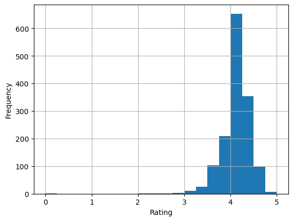

```python
# Ratings vs their count
df['rating'].hist(bins=20)
plt.xlabel('Rating')
plt.ylabel('Frequency')
plt.show()
```

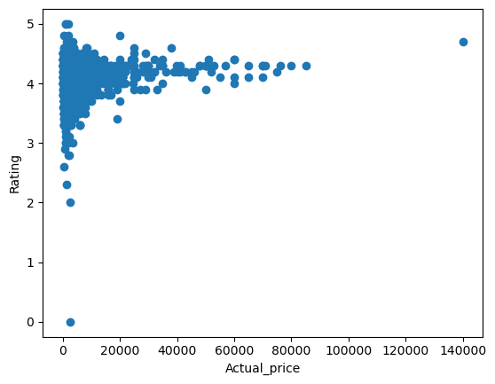

```python
# Plot actual_price vs. rating
plt.scatter(df['actual_price'], df['rating'])
plt.xlabel('Actual_price')
plt.ylabel('Rating')
plt.show()
```

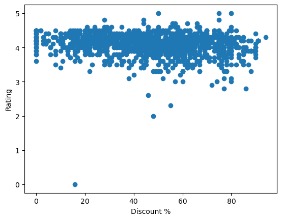

```python
# Plot discount_percentage vs. rating
plt.scatter(df['discount_percentage'], df['rating'])
plt.xlabel('Discount %')
plt.ylabel('Rating')
plt.show()
```

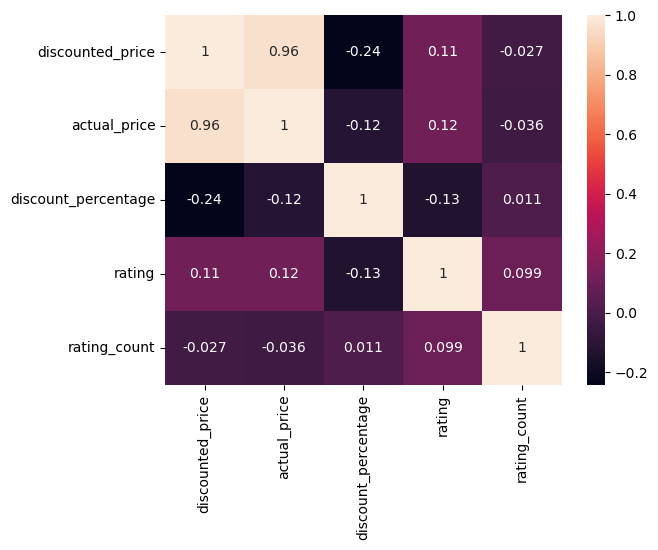

```python
# Plot correlations between numeric variables
sns.heatmap(df[numeric_columns].corr(), annot=True)
```

### EDA (Exploratory Data Analysis):

```python
# Top 10 most popular products
pd.set_option('display.max_colwidth', None)  # To display full length of content of columns

top_products = df[['product_name', 'rating_count', 'product_link']]\
                .sort_values(by='rating_count', ascending=False).head(10)
print(top_products)
```

```
                                                                                                     product_name  \
12                                      AmazonBasics Flexible Premium HDMI Cable (Black, 4K@60Hz, 18Gbps), 3-Foot
65                                                     Amazon Basics High-Speed HDMI Cable, 6 Feet (2-Pack),Black
47                            Amazon Basics High-Speed HDMI Cable, 6 Feet - Supports Ethernet, 3D, 4K video,Black
684                                     AmazonBasics Flexible Premium HDMI Cable (Black, 4K@60Hz, 18Gbps), 3-Foot
400                                               boAt Bassheads 100 in Ear Wired Earphones with Mic(Furious Red)
352                                                boAt Bassheads 100 in Ear Wired Earphones with Mic(Taffy Pink)
584                                                   boAt BassHeads 100 in-Ear Wired Headphones with Mic (Black)
370                  Redmi 9 Activ (Carbon Black, 4GB RAM, 64GB Storage) | Octa-core Helio G35 | 5000 mAh Battery
371   Redmi 9A Sport (Coral Green, 2GB RAM, 32GB Storage) | 2GHz Octa-core Helio G25 Processor | 5000 mAh Battery
473  Redmi 9A Sport (Carbon Black, 2GB RAM, 32GB Storage) | 2GHz Octa-core Helio G25 Processor | 5000 mAh Battery

     rating_count  \
12       426973.0
65       426973.0
```

[output cut: 20 more lines]

```python
# Most popular categories
df['category'].value_counts()
```

```
category
Computers&Accessories|Accessories&Peripherals|Cables&Accessories|Cables|USBCables                                          233
Electronics|WearableTechnology|SmartWatches                                                                                 76
Electronics|Mobiles&Accessories|Smartphones&BasicMobiles|Smartphones                                                        68
Electronics|HomeTheater,TV&Video|Televisions|SmartTelevisions                                                               63
Electronics|Headphones,Earbuds&Accessories|Headphones|In-Ear                                                                52
                                                                                                                          ...
Electronics|Cameras&Photography|Accessories|Batteries&Chargers|BatteryChargers                                               1
Computers&Accessories|NetworkingDevices|DataCards&Dongles                                                                    1
Electronics|HomeAudio|Speakers|MultimediaSpeakerSystems                                                                      1
OfficeProducts|OfficePaperProducts|Paper|Copy&PrintingPaper|ColouredPaper                                                    1
Home&Kitchen|Kitchen&HomeAppliances|Vacuum,Cleaning&Ironing|Vacuums&FloorCare|VacuumAccessories|VacuumBags|HandheldBags      1
Name: count, Length: 211, dtype: int64
```

```python
# Extract the main category
df['main_category'] = df['category'].str.split('|').str[0]

print(df[['category', 'main_category']].sample(5))

df['main_category'].value_counts()
```

```
                                                                                     category  \
1355  Home&Kitchen|Kitchen&HomeAppliances|WaterPurifiers&Accessories|WaterPurifierAccessories
1360                           Home&Kitchen|Heating,Cooling&AirQuality|RoomHeaters|FanHeaters
128                               Electronics|HomeTheater,TV&Video|Accessories|RemoteControls
1210    Home&Kitchen|Kitchen&HomeAppliances|WaterPurifiers&Accessories|WaterFilters&Purifiers
342                      Electronics|Mobiles&Accessories|Smartphones&BasicMobiles|Smartphones

     main_category
1355  Home&Kitchen
1360  Home&Kitchen
128    Electronics
1210  Home&Kitchen
342    Electronics
```

```
main_category
Electronics              526
Computers&Accessories    453
Home&Kitchen             448
OfficeProducts            31
MusicalInstruments         2
HomeImprovement            2
Toys&Games                 1
Car&Motorbike              1
Health&PersonalCare        1
Name: count, dtype: int64
```

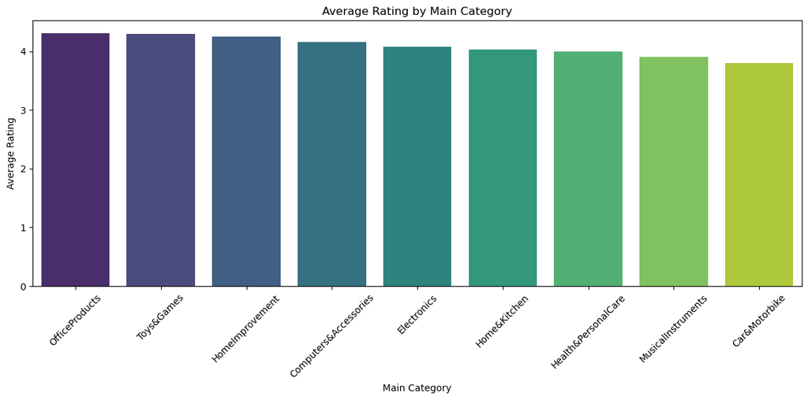

```python
# Calculate average rating per main_category
avg_ratings = df.groupby('main_category')['rating'].mean().reset_index()

# Sort by rating
avg_ratings = avg_ratings.sort_values(by='rating', ascending=False)

# Create bar plot
plt.figure(figsize=(12, 6))
sns.barplot(data=avg_ratings, x='main_category', y='rating', palette='viridis')

# Customize plot
plt.xticks(rotation=45)
plt.title('Average Rating by Main Category')
plt.xlabel('Main Category')
plt.ylabel('Average Rating')
plt.tight_layout()
plt.show()
```

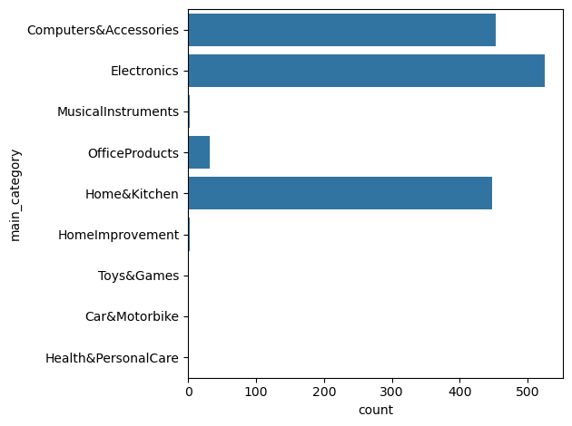

```python
# Number of products per category
sns.countplot(y='main_category', data=df)
plt.tight_layout()
plt.show()
```

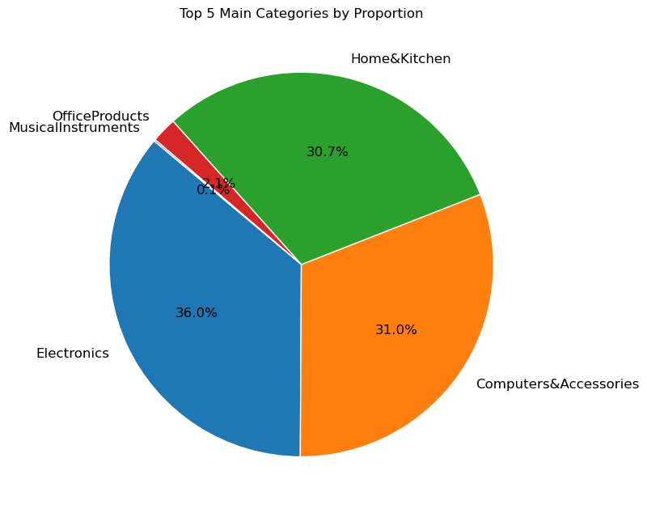

```python
# Plot the proportion of top 5 categories as a pie chart
plt.figure(figsize=(8, 8))  # Increase the figure size
df['main_category'].value_counts().head(5).plot.pie(
    autopct='%1.1f%%',
    startangle=140,
    wedgeprops={'edgecolor': 'white'},
    textprops={'fontsize': 12}
)
plt.ylabel('')  # Remove y-axis label
plt.title('Top 5 Main Categories by Proportion')
plt.tight_layout()
plt.show()
```

### **Sentiment Analysis**:

#### Method 1: Using NLTK VADER (Valence Aware Dictionary for sEntiment Reasoning)

Sentiment Analysis using VADER (Valence Aware Dictionary for sEntiment Reasoning) is a rule-based method for determining the emotional tone (positive, negative, neutral) of text, particularly designed to work well on social media, short texts, and informal language.

**Key points about VADER**:

*Lexicon-based*: Uses a dictionary where each word is assigned a sentiment score between -4 (most negative) and +4 (most positive).

*Handles social media slang*: Understands emoticons (:-)), acronyms (LOL), and slang words.

*Accounts for context*: Adjusts sentiment based on punctuation, capitalization, degree modifiers (e.g., very, extremely).

**Outputs four scores**:

*pos*: proportion of positive sentiment

*neu*: proportion of neutral sentiment

*neg*: proportion of negative sentiment

*compound*: a normalized score between -1 (most negative) and +1 (most positive)

```python
df['review_content']
```

```
0                                                                                                                                                                                                                                                                                                           …
1                                                                                                                                                                                                                                                                                                           …
2                                                                                                                                                                                                                                                                                                           …
3                                                                                                                                                                                                                                                                                                           …
4       Bought this instead of original apple, does the work for 150rs, not as fast as apple charger but its a good option if you want cheap and good product, bought it for iPad pro 10.5 and it's working flawlessly, build quality is ok, its not like i am gonna hang my clothes on it and i want a very…
                                                                                                                                                                                                                                                                                                            …
1460                                                                                                                                                                                                                                                                                                        …
1461                                                                                                                                                                                                                                                                                                        …
1462                                                                                                                                                                                                                                                                                                        …
1463                                                                                                                                                                                                                                                                                                        …
1464                                                                                                                                                                                                                                                                                                        …
Name: review_content, Length: 1465, dtype: object
```

```python
df['review_title']
```

```
0                                                                                                                                                                                                                   Satisfied,Charging is really fast,Value for money,Product review,Good quality,Good produ…
1                                                                                                                                                          A Good Braided Cable for Your Type C Device,Good quality product from ambrane,Super cable,As,Good quality,Good product,its good,Good quality for …
2                                                                                                                                                                                                      Good speed for earlier versions,Good Product,Working good,Good for the price,Good,Worth for money,Wor…
3                                                                                                                                                                                                   Good product,Good one,Nice,Really nice product,Very first time change,Good,Fine product but could be bet…
4                                                                                                                                                                                                     As good as original,Decent,Good one for secondary use,Best quality,GOOD,Amazing product at a mind blow…
                                                                                                                                                                          ...
1460                                                                                                                                                                                  Received the product without spanner,Excellent product,Satisfactory,Good product,great product,performance yet to be c…
1461    ok,everything was good couldn't return bcoz I needed it in emergency,Don't buy this 1 litre Prestige rice cooker. Already replaced but still got damaged product,Ideal for a small family of two.,Nice but small,Read the leaflets before you start cooking. Learn to use optimum quantity of water.…
1462                                                                                                                                                                                                                      very good,Work but front melt after 2 month,Good one,It is durable,Review.,DEFECTI…
1463                                                                                                                                                                                                                                             Fan Speed is slow,Good quality,Good product,good,Old is gol…
1464                                                                                                                      Works perfect,Ok good product,Nice Product. Recommend it. But cleaning its exterior is cumbersome.,Excellent product✌,A good product for household use,मुझे बिल्कुल भी मजा नहीं आय…
Name: review_title, Length: 1465, dtype: object
```

```python
# Download necessary NLTK resources
# nltk.download('stopwords')
# nltk.download('punkt')
# nltk.download('vader_lexicon')
# nltk.download('punkt_tab')  # Download the punkt_tab resource to avoid the LookupError

# Initialise english stopwords
stop_words = set(stopwords.words('english'))

# Initialize SentimentIntensityAnalyzer
sia = SentimentIntensityAnalyzer()

# Function to get stopwords from the review content
def get_stopwords_from_text(text):
    if isinstance(text, str):  # Ensure the text is a string
        words = word_tokenize(text.lower())  # Tokenize and convert to lower case
        stop_words_in_text = [word for word in words if word in stop_words]
        return stop_words_in_text
    return []  # Return empty list if text is not a valid string

# Function to analyze sentiment
def analyze_sentiment(text):
    if isinstance(text, str):  # Ensure the text is a string
        score = sia.polarity_scores(str(text))  # Always convert to string to avoid errors
        compound = score['compound']
        if compound >= 0.05:
            return 'positive'
        elif compound <= -0.05:
            return 'negative'
        else:
            return 'neutral'
    return 'neutral'  # Return 'Neutral' if text is not a valid string

# Apply the stopwords function and sentiment analysis
df['stopwords'] = df['review_title'].apply(get_stopwords_from_text)
df['sentiment_1'] = df['review_title'].apply(analyze_sentiment)

print(df[['review_title', 'stopwords', 'sentiment_1']])
```

```
                                                                                                                                                                                                                                                                                                            …
0                                                                                                                                                                                                                 Satisfied,Charging is really fast,Value for money,Product review,Good quality,Good product…
1                                                                                                                                                        A Good Braided Cable for Your Type C Device,Good quality product from ambrane,Super cable,As,Good quality,Good product,its good,Good quality for th…
2                                                                                                                                                                                                    Good speed for earlier versions,Good Product,Working good,Good for the price,Good,Worth for money,Worki…
3                                                                                                                                                                                                 Good product,Good one,Nice,Really nice product,Very first time change,Good,Fine product but could be bette…
4                                                                                                                                                                                                   As good as original,Decent,Good one for secondary use,Best quality,GOOD,Amazing product at a mind blowin…
...                                                                                                                                                                                                                                                                                                         …
1460                                                                                                                                                                                Received the product without spanner,Excellent product,Satisfactory,Good product,great product,performance yet to be che…
1461  ok,everything was good couldn't return bcoz I needed it in emergency,Don't buy this 1 litre Prestige rice cooker. Already replaced but still got damaged product,Ideal for a small family of two.,Nice but small,Read the leaflets before you start cooking. Learn to use optimum quantity of water.,Q…
1462                                                                                                                                                                                                                    very good,Work but front melt after 2 month,Good one,It is durable,Review.,DEFECTIVE…
1463                                                                                                                                                                                                                                           Fan Speed is slow,Good quality,Good product,good,Old is gold.…
1464                                                                                                                    Works perfect,Ok good product,Nice Product. Recommend it. But cleaning its exterior is cumbersome.,Excellent product✌,A good product for household use,मुझे बिल्कुल भी मजा नहीं आया …

                                                                             stopwords  \
0                                                               [is, for, as, of, now]
```

[output cut: 25 more lines]

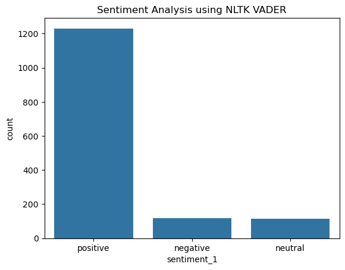

```python
# Plot Sentiment Distribution
sns.countplot(x='sentiment_1', data=df)
plt.title("Sentiment Analysis using NLTK VADER")
plt.show()
```

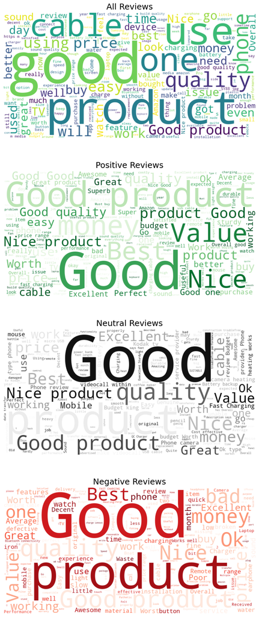

```python
# Combine texts by sentiment
all_reviews = ' '.join(df['review_content'].astype(str)) # all_reviews is a single string containing all the review texts in the dataset, separated by spaces.
positive_reviews = ' '.join(df[df['sentiment_1'] == 'positive']['review_title'].astype(str))
neutral_reviews = ' '.join(df[df['sentiment_1'] == 'neutral']['review_title'].astype(str))
negative_reviews = ' '.join(df[df['sentiment_1'] == 'negative']['review_title'].astype(str))

# Generate word clouds
wordclouds = {
    'All Reviews': WordCloud(width=800, height=400, background_color='white', colormap='viridis').generate(all_reviews),
    'Positive Reviews': WordCloud(width=800, height=400, background_color='white', colormap='Greens').generate(positive_reviews),
    'Neutral Reviews': WordCloud(width=800, height=400, background_color='white', colormap='gray').generate(neutral_reviews),
    'Negative Reviews': WordCloud(width=800, height=400, background_color='white', colormap='Reds').generate(negative_reviews),
}

# Plot in subplots
fig, axs = plt.subplots(4, 1, figsize=(14, 20))

for i, (title, wc) in enumerate(wordclouds.items()):
    axs[i].imshow(wc, interpolation='bilinear')
    axs[i].set_title(title, fontsize=18)
    axs[i].axis('off')

plt.tight_layout(pad=5.0)
plt.show()
```

### Method 2 : Using deep learning model: HuggingFace Transformers (BERT-based Roberta pretrained model)

Sentiment Analysis using Deep Learning Models (Hugging Face Transformers, e.g., BERT-based RoBERTa) is a data-driven approach where a pre-trained transformer model understands the meaning of text and predicts its sentiment (positive, negative, neutral, etc.) based on learned patterns from large datasets.

**Key Concepts-**

*Transformer Architecture:* Uses self-attention mechanisms to understand word meaning in context (e.g., "bank" in "river bank" vs "money bank").

*RoBERTa Model:* Stands for Robustly Optimized BERT Approach. Trained on more data and with better hyperparameters than BERT for higher accuracy. Available as pre-trained weights in Hugging Face’s transformers library.

*Transfer Learning:* The pre-trained model is fine-tuned on sentiment-labeled data (e.g., movie reviews, tweets) to classify text into sentiment categories.

**Advantages over VADER:**

Captures nuance and context better.

Works well with longer, complex text.

Can adapt to domain-specific language with fine-tuning.

```python
# Load model and tokenizer
model_name = "cardiffnlp/twitter-roberta-base-sentiment"
tokenizer = AutoTokenizer.from_pretrained(model_name)
model = AutoModelForSequenceClassification.from_pretrained(model_name)

# Define label mapping (based on model order)
labels = ['negative', 'neutral', 'positive']

# Function to get the sentiment label with highest probability
def get_sentiment_label(text):
    encoded_input = tokenizer(str(text), return_tensors='pt', truncation=True)
    with torch.no_grad():
        output = model(**encoded_input)
    scores = output.logits[0]
    probabilities = torch.nn.functional.softmax(scores, dim=0)
    predicted_class = torch.argmax(probabilities).item()
    return labels[predicted_class]

# Apply on the DataFrame
df['sentiment_2'] = df['review_title'].apply(get_sentiment_label)

# Preview
print(df[['review_title', 'sentiment_2']].head())
```

```
Asking to truncate to max_length but no maximum length is provided and the model has no predefined maximum length. Default to no truncation.
```

```
                                                                                                                                                                            review_title  \
0                                                           Satisfied,Charging is really fast,Value for money,Product review,Good quality,Good product,Good Product,As of now seems good
1  A Good Braided Cable for Your Type C Device,Good quality product from ambrane,Super cable,As,Good quality,Good product,its good,Good quality for the price but one issue with my unit
2                                              Good speed for earlier versions,Good Product,Working good,Good for the price,Good,Worth for money,Working nice,it's a really nice product
3                                           Good product,Good one,Nice,Really nice product,Very first time change,Good,Fine product but could be better,Very nice it's charging like jet
4                                             As good as original,Decent,Good one for secondary use,Best quality,GOOD,Amazing product at a mind blowing price!,Nice Quality,Good product

  sentiment_2
0    positive
1    positive
2    positive
3    positive
4    positive
```

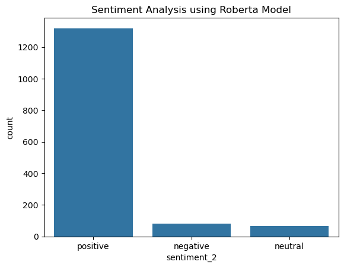

```python
# Plot Sentiment Distribution
sns.countplot(x='sentiment_2', data=df)
plt.title("Sentiment Analysis using Roberta Model")
plt.show()
```

```python
print("Sentiment 1 counts (VADER):")
print(df['sentiment_1'].value_counts())
print()

print("Sentiment 2 counts (RoBERTa):")
print(df['sentiment_2'].value_counts())
```

```
Sentiment 1 counts (VADER):
sentiment_1
positive    1231
negative     119
neutral      115
Name: count, dtype: int64

Sentiment 2 counts (RoBERTa):
sentiment_2
positive    1320
negative      80
neutral       65
Name: count, dtype: int64
```

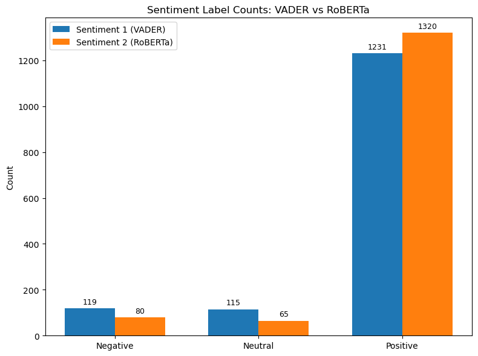

```python
# Count sentiment labels
sentiment1_counts = df['sentiment_1'].value_counts().reindex(['negative', 'neutral', 'positive'], fill_value=0)
sentiment2_counts = df['sentiment_2'].value_counts().reindex(['negative', 'neutral', 'positive'], fill_value=0)

# Labels and positions
labels = ['Negative', 'Neutral', 'Positive']
x = np.arange(len(labels))  # label locations
width = 0.35  # width of the bars

# Plot
fig, ax = plt.subplots(figsize=(8, 6))
bars1 = ax.bar(x - width/2, sentiment1_counts, width, label='Sentiment 1 (VADER)', color='#1f77b4')
bars2 = ax.bar(x + width/2, sentiment2_counts, width, label='Sentiment 2 (RoBERTa)', color='#ff7f0e')

# Labels & title
ax.set_ylabel('Count')
ax.set_title('Sentiment Label Counts: VADER vs RoBERTa')
ax.set_xticks(x)
ax.set_xticklabels(labels)
ax.legend()

# Annotate bars
for bar in bars1 + bars2:
    height = bar.get_height()
    ax.annotate(f'{int(height)}',
                xy=(bar.get_x() + bar.get_width() / 2, height),
                xytext=(0, 3),  # vertical offset
                textcoords="offset points",
                ha='center', va='bottom', fontsize=9)

plt.tight_layout()
plt.show()
```